# R 機率預測評估方法

Ivan Lin

2020年4月23日

在前一篇[數值預估評估方法](https://rpubs.com/ivan0628/numerical_model_evaluation)，已介紹我們進行數值預測時，怎麼評估模型的好壞，在這篇，我們來介紹機率預測模型的評估方法。

前情提要

## 模型評估-驗證指標(validation index)

若將預測這件事簡單區分成兩大種類，大致可分為  
1. 機率預測，比如會不會下雨、下一張牌的紅心A…  
2. 數值預測，比如預測下一季的銷售量、捷運站的客流量…  
我們利用所蒐集到的資料訓練出模型進行預測，然而怎麼評估模型成效(Performance)呢？

我們會使用驗證指標(validation index)來當作成效參考，對應到機器學習領域，依據應用分為「分類指標」和「回歸指標」。

**機率預測的「分類指標」**:  
- 二元相關：混淆矩陣confusion matrix和相對應驗證指標、ROC曲線、AUC。  
- 多元相關：多元混淆矩陣和相對應驗證指標。

**數值預測的「回歸指標」**:  
- 絕對誤差(Absolute Error, E)、相對誤差(Relative Error, e)  
- 平均絕對誤差(Mean Absolute Error, MAE)  
- 平均均方誤差(Mean Squared Error, MSE)  
- 平均均方對數誤差(Mean Squared Logarithmic Error, MSLE)  
- 正歸化均方誤差、均方根誤差

## 二元機率預測

本篇先從簡單的二元預測開始，甚麼是二元預測呢？舉例來說就是答案非正即負，例如：發生或不發生；正面或反面；A類或B類；下雨或不下雨，兩種情況的預測。記得以前研究所時，我們的專題是將山坡地切割成數公尺方形網格，利用機率預測判斷這個網格是否有可能山崩，這也是一種二元的機率預測。

複習一下統計學，機率是指事情出現的可能性，是對分類問題中某種類別出現的機率的描述。

## 混淆矩陣

混淆矩陣是最廣泛且最基本用來評估分類模型的方式，這邊舉例講解會較清楚。  
假設有間醫院有500個疑似流感患者的病人做篩檢，其中實際有得到流感的人數是150人，未得到的是350人，然而醫院使用快篩法解省時間成本，但快篩法的結果是得到流感的有155人，未得到的有345人，其中包含有得到卻錯誤被篩為未得病的偽陰性15人，還有明明沒有流感卻被誤判為陽性的20人。這種文字敘述是不是讓人覺得很冗長也難理解呢？若我們做成誤差矩陣就一目了然！

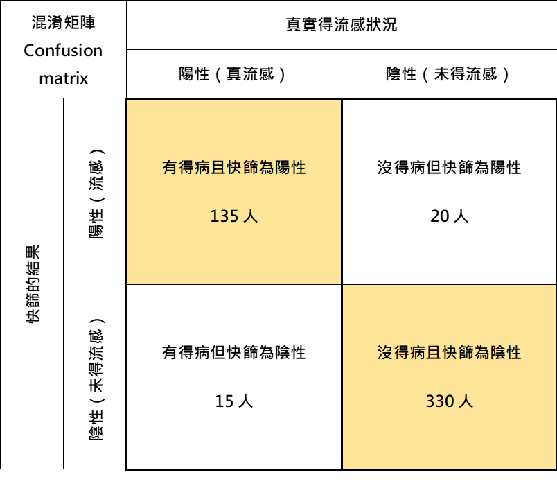

對角線黃色區塊，代表快篩結果判斷正確的人數，另一邊未填色的則是快篩判斷錯誤的人數。  
從圖上我們可以計算各種佔比變且轉化成機率表示，例如有得病卻篩檢錯誤的機率15/150=10%…

接下來我們就來介紹各種誤差矩陣算出來的各種數值！

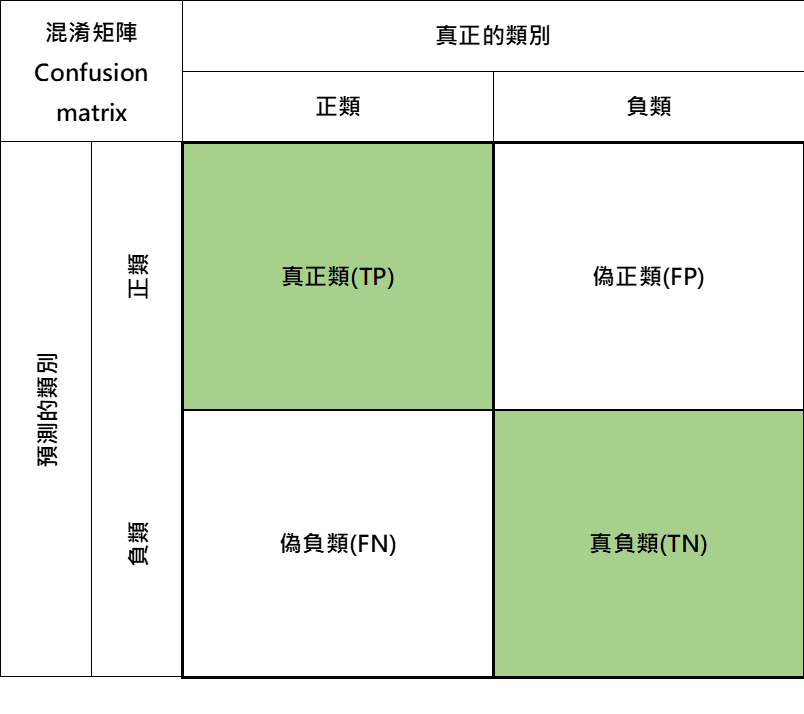

我們從左上角順時鐘介紹：  
當一個正類的資料點被預測為正值，即為真正類（ True positive, TP），如圖左上；  
當一個負類的資料點被預測為正值，即為偽正類（False positive, FP），如圖右上；  
當一個負類的資料點被預測為負值，即為真負類（ True negative, TN），如圖右下；  
當一個正類的資料點被預測為負值，即為偽負類（False negative, FN），如圖左下。

直覺上，TP與TN可能是大眾直覺關注的地方。因為如果模型有很高的TP和TN值，就表示模型預測的正確性很高。  
但對於我們在訓練模型時，更在意FP和FN，因為專注於改善錯誤，更有助於調整模型。

透過混淆矩陣，我們很方便計算以下評估指標：

這些指標在統計學與機器學習有不同的慣用翻譯，以下介紹採用ML領域常見的用法，並盡我所知的補充。

## 總體比率：

### 總體準確率(Accuracy, Acc)

模型總體的準確率，有被正確預測的數量佔總體的比值，這個比值當然希望越高越好！
$$Acc=\frac{TP+TN}{TP+TN+FP+FN}$$
利用上述流感的例子，$TA=(135+330)/500=0.93$

### 總體錯誤率(Total Error Rate, TER)

指模型總體預測錯誤的比率，與總體準確率Accrucy和為1。
$$TER=\frac{FP+FN}{Total}=1-Acc$$
流感例子為$TER=(20+15)/500=0.07$

## 佔預測分類的邊際機率：

以預測為正或預測為負總數當作分母

### 精準度(Percision)

又稱為正元符合率，陽性預測值Positive predictive value(PPV)，指模型中正確預測正樣本的數量佔預測為正數量的比值，是經常被用到的指標。
$$Percision=\frac{TP}{TP+FP}$$
流感例子的$P=135/155=0.87$

### 錯誤率(False Discovery Rate, FDR)

指模型錯誤地預測正樣本(稱為：型一錯誤)偽陽性的數量佔預測為正樣本的數量比值。對比於精準度(Percision)
$$FDR=\frac{FP}{TP+FP}$$
流感例子為$FDR=20/155=0.13$

## 佔實際分類的邊際機率：

以實際為正或實際為負總數當作分母

### 召回率(Recall)

又稱為真正率(True Positive Rate, TPR)、覆蓋率(Coverage Rate, CR)、靈敏度(Sensitivity)、查全率、擊中率或命中率。
它表示模型中被正確預測為正的樣本佔全體正樣本的比值，對於一些重要的事件預測，比如說疾病，這些關注的事件能不能有效被模型分類很重要。
$$Recall=\frac{TP}{TP+FN}$$
流感例子的$Recall=135/150=0.9$ 若把流感改為最近影響世界的武漢肺炎，十個染病帶源者接受篩選，會有一個被誤判為陰性，雖然召回率高達九成，但那一成偽陰性誤判結果對防疫仍是很難接受的。

### 特異性(Specficity)

又稱為真負率(True Negative Rate, TNR)、負元覆蓋率(Negative Coverage Rate, NCR)、負元召回率、負元查全性。
它表示模型中被正確預測為負樣本佔全體負樣本的比值。
$$Specficity=\frac{TN}{FP+TN}$$
流感例子的$Specficity=330/350=0.94$

### 假負率 FNR

這裡引用網路上 [Tommy大神](https://medium.com/@chih.sheng.huang821/%E6%A9%9F%E5%99%A8%E5%AD%B8%E7%BF%92-%E7%B5%B1%E8%A8%88%E6%96%B9%E6%B3%95-%E6%A8%A1%E5%9E%8B%E8%A9%95%E4%BC%B0-%E9%A9%97%E8%AD%89%E6%8C%87%E6%A8%99-b03825ff0814)整理的指標計算表

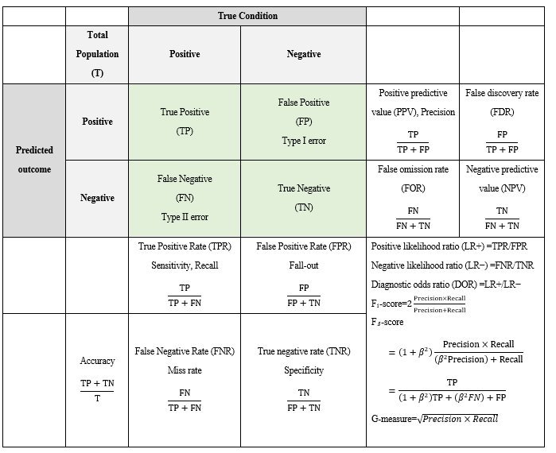

非常強大！

從這張圖可以很容易計算邊際機率，並能了解各參數彼此消長的情況。

缺點： 實務上很難單單從一個指標就判定這個模型的好壞，舉例來說，如果我們的模型是要預測廠房跳電的發生，可能一兩年才會發生一次，樣本非常少，這時候模型只要把99%的日子都歸納為陰性，一樣可以得到很高的精準度，但是真正斷電的時候模型也完全無法察覺！這個準確率99%的模型就不是我們想要的。在正負樣本數量不行衡的情況下，單看準確率就有很大的缺陷。  
另外，製表前我們必須設定分類的門檻值，一般先設定為0.5，但實際上哪個值門檻最佳無法單從誤差矩陣直觀選取。

```r
#install.packages('ROCR')
#require(ROCR)

#用ROCR套件中的範例資料集
data("ROCR.simple")
df <- data.frame(ROCR.simple)
df$predclass <- ifelse(df$predictions>0.5, 1, 0) #用0.5當作門檻值
print(cf <- table(df[,c("predclass","labels")]))
```

```
##          labels
## predclass  0  1
##         0 91 14
##         1 16 79
```

```r
tp <- cf[2, 2]
tn <- cf[1, 1]
fp <- cf[2, 1]
fn <- cf[1, 2]
accuracy <- (tp + tn)/(tp + tn + fp + fn); accuracy
```

```
## [1] 0.85
```

```r
sensitivity <- tp/(tp + fn); sensitivity
```

```
## [1] 0.8494624
```

```r
specificity <- tn/(tn + fp); specificity
```

```
## [1] 0.8504673
```

```r
#install.packages('caret')
#require(caret)

confusionMatrix(cf, positive = "1")
```

```
## Confusion Matrix and Statistics
##
##          labels
## predclass  0  1
##         0 91 14
##         1 16 79
##
##                Accuracy : 0.85
##                  95% CI : (0.7928, 0.8965)
##     No Information Rate : 0.535
##     P-Value [Acc > NIR] : <2e-16
##
##                   Kappa : 0.6989
##
##  Mcnemar's Test P-Value : 0.8551
##
##             Sensitivity : 0.8495
##             Specificity : 0.8505
##          Pos Pred Value : 0.8316
##          Neg Pred Value : 0.8667
##              Prevalence : 0.4650
##          Detection Rate : 0.3950
##    Detection Prevalence : 0.4750
##       Balanced Accuracy : 0.8500
##
##        'Positive' Class : 1
##
```

以上是直接觀察計算就可以得到的一級指標，透過上述的值，我們還可以進一步推算二級、三級指標。

## F值

又稱為F-Measure或F-Score，它是精準度Precision $P=\frac{TP}{TP+FP}$和召回率Recall $R=\frac{TP}{TP+FN}$的加權調合平均值。  
調合平均值？嘿！沒錯，就是我們以前算總電阻的時候會用倒數相加的那個。 對模型而言，當然希望精準度與召回率都越高越好，但是兩者卻彼此消長，提高P的同時可能導致R降低，這就是魚與熊掌的難題。

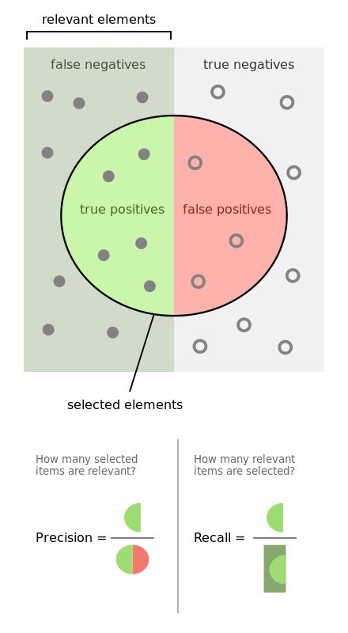

故要調較模型時便須有所取捨，這時候該怎麼抉擇呢？通常這當中有一個平衡點，這裡F值就派上用場了！
$$F_{\alpha}=\frac{1}{\frac{\alpha}{P}+\frac{1-\alpha}{R}}=\frac{P\cdot R}{\alpha \cdot R+(1-\alpha) \cdot P}$$
另外，
$$\frac{1}{F_{\beta}}=\frac{1}{(\beta^{2}+1)} \times (\frac{1}{P} +\frac{\beta^{2}}{R})$$
$$F_{\beta}=\frac{(\beta^{2}+1)\cdot P\cdot R}{\beta^{2} \cdot P+R}$$
若想知道公式推導，可以參考 [Stackexchange](https://stats.stackexchange.com/questions/221997/why-f-beta-score-define-beta-like-that)
當$\alpha=0.5$或$\beta=1$時，就成為常見的F1-Measure了，這裡的1就是指β。
$$F_{1}=\frac{2 \cdot P \cdot R}{P+R}$$
$$F_{1} \in [0,1]$$
而$\alpha,\beta$值代表甚麼呢？這兩值的大小表示召回率對精準度的相對重要程度。
當β=1時，稱為F1-score，這時，精準度和召回率都很重要，權重相同。但有些情況下，我們認為精準度更重要一點，那就調整β的值小於1，當我們認為召回率比較重要，那就調整β的值大於1。 [Wiki](https://en.wikipedia.org/wiki/F1_score)
β=1，召回率的權重=精準度的權重，得到F1；
β>1，召回率的權重>精準度的權重；
β<1，召回率的權重<精準度的權重。
常用的還有$F_{0.5}$、$F_{2}$。

當$F_{1}$接近1時表示模型好，反正靠近0時則不好，一般來說我們只要比較兩個模型的F1值就可以分辨模型良莠。  
但麻煩的問題又來了，如果你有兩個模型A與B:  
A的精準度為90%，召回率為80%  
B的精準度為80%，召回率為90%  
兩個模型會有相同的F1值。